# Lire les données depuis un carnet Jupyter

**Notions et fonctions**  
. Les notions et procédures apparaissant pour la première fois dans le cours sont suivies d'un astérisque

- Import donnés par Api*
- Chargement données tabulées
- Chargement données Json *

**Comme d'habitude certaines cellules sont dépendantes de cellules précédentes. Il faut donc les éxécuter en suivant leur ordre dans la page**

**révisions**

Pour analyser des données il faut bien sûr pouvoir les appeller dans votre carnet Jupyter. La force de ceux-ci est qu'il est possible de le faire à partir de sources et de formats divers, au moyen de procédures spécifiques.

## Données tabulées

Vous disposerez souvent de données tabulées sous la forme de fichiers csv.

```python
#Nous allons utiliser la bib panda, il faut donc l'importer
# pour simplifier son usage nous la renommons pd
import pandas as pd
df=pd.read_csv('docs3data/excsv.csv')
```

```python
# Nous vérifions la qualité de l'import en visualisant les premières lignes
df.head()
```

|  | Unnamed: 0 | A | B | X | D |
| --- | --- | --- | --- | --- | --- |
| 0 | Toto | 2 | 12 | 43 | 1 |
| 1 | Gudule | 3 | 4 | 5 | 3 |
| 2 | Nanar | 3 | 25 | 5 | 5 |

Par défaut le séparateur est la virgule. Il peut arriver que vous obteniez un message d'erreur parce que le fichier dont vous disposez use d'un ature séparateur. Un paramètre de la fonction permet de préciser le séparateur utilisé selon la syntaxe ci-dessous df = pd.read_csv('chemin/vers/votre/fichier.csv', sep=';') Le séparateur ici est le ; signalé par le paramètre sep

## Depuis un tableau XL

Pandas vous permet d'importer facilement des fichies XL et d'interagir avec ceux ci avec une fonction similaire **Attention** Openpyxl doit être installé dans l'environnement pour pouvoir manipuler les fichiers xl. Il n'est pas besoin de l'appeler dans le carnet pour l'utiliser.

```python
df = pd.read_excel('docs3data/exexcl.xlsx')
# Les fichiers xl n'ont pas tous la même structure (fichiers anciens en xls par exemple)
# des aménagements peuvent être nécessaires en ce cas. Pour ouvrir un fichier .xls vous devez souvent installer la bib. xlrd
```

```python
#Nous vérifions
df.head()
```

|  | Unnamed: 0 | A | B | X | D |
| --- | --- | --- | --- | --- | --- |
| 0 | Toto | 2 | 12 | 43 | 1 |
| 1 | Gudule | 3 | 4 | 5 | 3 |
| 2 | Nanar | 3 | 25 | 5 | 5 |

## Données obtenues par une api

De plus en plus de données sont accessibles par le biais d'une api, qui peuvent être intégrées dans une dataframe puis exploitées. Le passage par le code est ici particulièrement intéressant parce que vous pouvez tirer parti des actualisations de la banque de données simplement en relançant la cellule.  
La cellule ci dessous donne un exemple à partir d'une API crée auprès de the movie database, nous demandons la liste des catégories.

```python
import requests
#nous avons beosin de la bib. request

url = "https://api.themoviedb.org/3/genre/movie/list?language=en"
#l'adresse à laquelle se trouvent les données. Généralement le site la fournit dans sa documentation

# Nous devons montrer patte blanche et nous authentifier avant d'obtenir les données



headers = {
    "accept": "application/json",
    "Authorization": "Bearer eyJhbGciOiJIUzI1NiJ9.eyJhdWQiOiJkOTQ2NWVmZTUwOWExOWNhMmNjMzZlMmQ2MjRhMWMwNCIsInN1YiI6IjY1ZDZmZDYxMjVjZDg1MDE4NjdmOWNjYSIsInNjb3BlcyI6WyJhcGlfcmVhZCJdLCJ2ZXJzaW9uIjoxfQ.CiJICbtbaweYU5EiPfC2S_SX-j-DlSqBrQo8GW1JfXc"
}
# Nous demandons la liste des valeurs possibles de la variable genre
response = requests.get(url, headers=headers)
# nous visualisons la réponse
print(response.text)
# La réponse est fournie en json il faudra, nous y reviendrons, quelques transformations afin de rendre ce type de données utilisables
```

```
{"genres":[{"id":28,"name":"Action"},{"id":12,"name":"Adventure"},{"id":16,"name":"Animation"},{"id":35,"name":"Comedy"},{"id":80,"name":"Crime"},{"id":99,"name":"Documentary"},{"id":18,"name":"Drama"},{"id":10751,"name":"Family"},{"id":14,"name":"Fantasy"},{"id":36,"name":"History"},{"id":27,"name"…
```

## Fichiers Json

De plus en plus fréquemment les gisements de données, et pas seulement les API offrent l'accès à des fichies json, dont la structure peut être complexe.  
Obtenir un dataframe exploitable à partir de ceux-ci n'est pas toujours simple, la chose est cependant possible avec Python ... si l'on parvient à manipuler les listes et les dictionnaires, notions sur lesquelles nous reviendrons.  
Vous trouverez ci dessous un exemple, destiné uniquement à montrer qu'il est possible (mais c'est évidemment plus difficile) de manier ce genre de données.

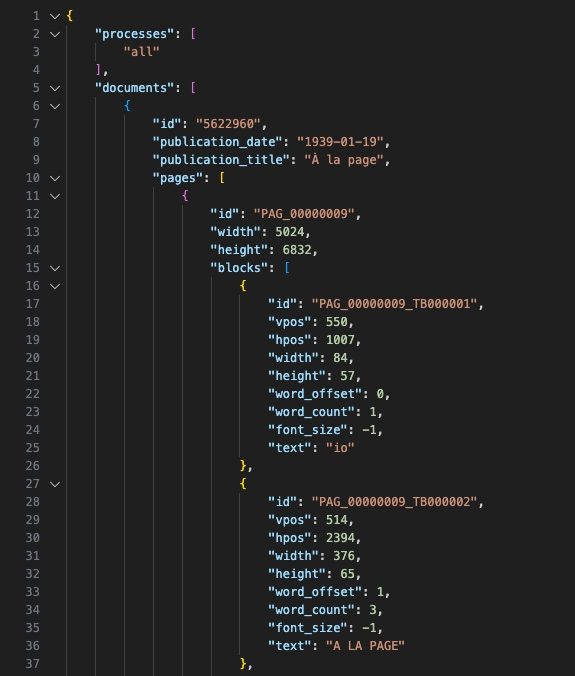

```python
from IPython.display import Image
Image(filename='docs3data/jso.jpg')
```

Nous souhaitons créer un data frame contenant les blocs de texte contenant une chaîne de caractère spécifique, en gardant pour chacun de ces blocs les éléments permettant de le situer (la date et le titre de la publication)

```python
import json

# Remplacez 'chemin/vers/votre/fichier.json' par le chemin de votre fichier
with open('docs3data/ex.json', 'r') as file:
    data = json.load(file)

# Nous chargeons le fichier dans une variable nommée data pour pour pouvoir le manipuler
```

```python
#Nous utilisons ici un document produit à l'aide d'une extraction d'information depuis retronews
# Nous souhaitons extraire les blocs de textes contenant le terme extradition en conservant la date de parution et le titre du journal

# je crée une liste qui va contenir les éléments extraits du fichier
rows = []


for document in data['documents']:
    publication_date = document.get('publication_date')
    publication_title = document.get('publication_title')
# une boucle for permet d'itérer une même opération pour tous les 'document' contenus dans le dictionnaire data contenant une liste de documents
# La méthode get permet d'extraire de chaque document la date de publication et le titre
# Nous parcourons chaque bloc, de chaque page, de chaque document
    for page in document.get('pages', []):
        for block in page.get('blocks', []):
            text = block.get('text', '')

            if "extrad" in text.lower():
                # Vérifier si 'extrad' est dans le texte du block, la méthode lower est insensible à la case
                row = {
                    "publication_date": publication_date,
                    "publication_title": publication_title,
                    "texte": text
                }
#nous créons un dictionnaire chaque fois que la valeur cherchée est trouvée contenant les trois variables définies
                rows.append(row)
#nous ajoutons le dictionnaire row à la liste rows (qui est une liste de dictionnaires)
# Créer le DataFrame
df = pd.DataFrame(rows)

# Afficher le DataFrame
print(df)
```

```
  publication_date publication_title  \
0       1939-01-19         À la page

                                               texte
0  mon argent sans .me. faire connaître : je sera...
```

```python
# Enregistrer le DataFrame dans un fichier CSV
df.to_csv('article.csv', index=False)
```

## Une collection de fichiers json

Nous obtenons parfois (souvent) en réponse à une requête une collection de fichiers json, Python nous permet là aussi au prix de quelques lignes de codes de disposer d'un matériau exploitable

```python
import os


# Initialiser une liste pour stocker les données extraites
rows = []

# Spécifier le chemin du répertoire contenant les fichiers JSON
directory = 'extrad'

# Itérer sur tous les fichiers dans le répertoire et sous-répertoires
# nous ouvrons un à un chaque fichier json présent dans le dossier
for root, dirs, files in os.walk(directory):
    for filename in files:
        if filename.endswith('.json'):
            filepath = os.path.join(root, filename)

            # Charger les données JSON du fichier
            with open(filepath, 'r') as file:
                data = json.load(file)

            # Extraire les informations de chaque document
            for document in data['documents']:
                publication_date = document.get('publication_date')
                publication_title = document.get('publication_title')

                for page in document.get('pages', []):
                    for block in page.get('blocks', []):
                        text = block.get('text', '')
                        if "extrad" in text.lower():
                            row = {
                                "publication_date": publication_date,
                                "publication_title": publication_title,
                                "texte": text
                            }
                            rows.append(row)

# Créer le DataFrame à partir des données extraites
df = pd.DataFrame(rows)

# Enregistrer le DataFrame dans un fichier CSV
df.to_csv('test.csv', index=False)
```

```python
print(df)
```

```
   publication_date                                  publication_title  \
0        1871-09-03                         Courrier de Saône-et-Loire
1        1871-06-03                         Courrier de Saône-et-Loire
2        1871-12-24                         Courrier de Saône-et-Loire
3        1871-05-12                         Courrier de Saône-et-Loire
4        1871-06-02                         Courrier de Saône-et-Loire
5        1871-06-05                         Courrier de Saône-et-Loire
6        1871-06-05                         Courrier de Saône-et-Loire
7        1871-09-15                      Archives israélites de France
8        1871-06-17                                 Feuille de Provins
9        1871-06-01                             Courrier de la Gironde
10       1871-05-10                             Courrier de la Gironde
11       1871-05-28                             Courrier de la Gironde
12       1871-05-16                             Courrier de la Gironde
13       1871-06-09                             Courrier de la Gironde
```

[output cut: 52 more lines]

relu 16 mars 24 OK